# Quiz

#### 연습 문제 4.4.1

여러가지 함수를 사용하여 아래 조건에 맞는 그래프를 그린다.

- xlabel, ylabel, title을 모두 갖추고 있어야 한다.
- 하나의 Figure(일단, 그림이라고 이해한다. 아래에 자세한 설명이 있다.)에 3개 이상의 Plot을 그린다.
- 각 Plot은 다른 선, 마크, 색 스타일을 가진다.
- legend는 그래프와 겹치지 않는 곳에 위치 시키도록 한다.

```python
# 그래프를 노트북 안에 그리기 위해 설정
%matplotlib inline
# 필요한 패키지와 라이브러리를 가져옴
import numpy as np
import pandas as pd
import matplotlib as mpl
import matplotlib.pyplot as plt
import matplotlib.font_manager as fm
# 그래프에서 마이너스 폰트 깨지는 문제에 대한 대처
mpl.rcParams['axes.unicode_minus'] = False
```

```python
[(f.name, f.fname) for f in fm.fontManager.ttflist if 'Malgun' in f.name]
plt.rcParams["font.family"] = 'Malgun Gothic'
plt.rcParams["font.size"] = 10
```

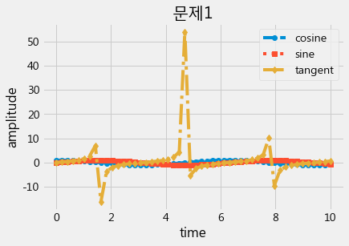

```python
plt.style.use('fivethirtyeight')
X = np.linspace(0, 10)
C, S, T = np.cos(X), np.sin(X), np.tan(X)
plt.plot(X, C, ls="--", label="cosine", marker="o")
plt.plot(X, S, ls=":", label="sine", marker="s",)
plt.plot(X, T, ls="-.", label="tangent", marker="d")
plt.legend(loc=0)
plt.xlabel("time")
plt.ylabel("amplitude")
plt.title("문제1")
plt.show()
```

#### 연습 문제 4.3.2

여러가지 함수를 사용하여 위와 같이 subplot들로 구성된 그림을 그려보자. 모든 subplot에 대해 xlabel, ylabel, title이 있어야 한다.

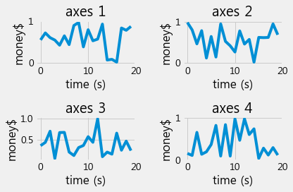

```python
np.random.seed(0)

plt.subplot(221)
plt.plot(np.random.rand(20))
plt.title("axes 1")
plt.xlabel('time (s)')
plt.ylabel('money$')

plt.subplot(222)
plt.plot(np.random.rand(20))
plt.title("axes 2")
plt.xlabel('time (s)')
plt.ylabel('money$')

plt.subplot(223)
plt.plot(np.random.rand(20))
plt.title("axes 3")
plt.xlabel('time (s)')
plt.ylabel('money$')

plt.subplot(224)
plt.plot(np.random.rand(20))
plt.title("axes 4")
plt.xlabel('time (s)')
plt.ylabel('money$')

plt.tight_layout()
plt.show()
```

#### 연습 문제 4.3.3

1. Matplotlib 갤러리 웹사이트에서 관심있는 예제 코드를 하나 고른다.
   - http://matplotlib.org/gallery.html
2. 예제 코드에 사용된 Matplotlib API 명령의 목록을 만들고 Matplotlib 웹사이트에서 관련 링크를 찾아 내용을 정리한다.
3. 변형된 형태의 플롯을 만들어본다.

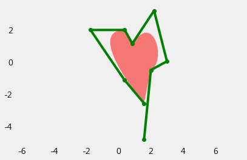

```python
import matplotlib.path as mpath
import matplotlib.patches as mpatches

fig, ax = plt.subplots()

Path = mpath.Path
path_data = [
    (Path.MOVETO, (1.58, -2.57)),
    (Path.CURVE4, (0.35, -1.1)),
    (Path.CURVE4, (-1.75, 2.0)),
    (Path.CURVE4, (0.375, 2.0)),
    (Path.LINETO, (0.85, 1.15)),
    (Path.CURVE4, (2.2, 3.2)),
    (Path.CURVE4, (3, 0.05)),
    (Path.CURVE4, (2.0, -0.5)),
    (Path.CLOSEPOLY, (1.58, -4.8)),
    ]
codes, verts = zip(*path_data)
path = mpath.Path(verts, codes)
patch = mpatches.PathPatch(path, facecolor='r', alpha=0.5)
ax.add_patch(patch)

x, y = zip(*path.vertices)
line, = ax.plot(x, y, 'go-')

ax.grid()
ax.axis('equal')
plt.show()
```

#### matplotlib.path

A module for dealing with the polylines used throughout Matplotlib.

The primary class for polyline handling in Matplotlib is Path. Almost all vector drawing makes use of Paths somewhere in the drawing pipeline.

Whilst a Path instance itself cannot be drawn, some Artist subclasses, such as PathPatch and PathCollection, can be used for convenient Path visualisation.

```python
# class matplotlib.path.Path(vertices, codes=None, _interpolation_steps=1,
# closed=False, readonly=False)
```